# Team

### Lab Members

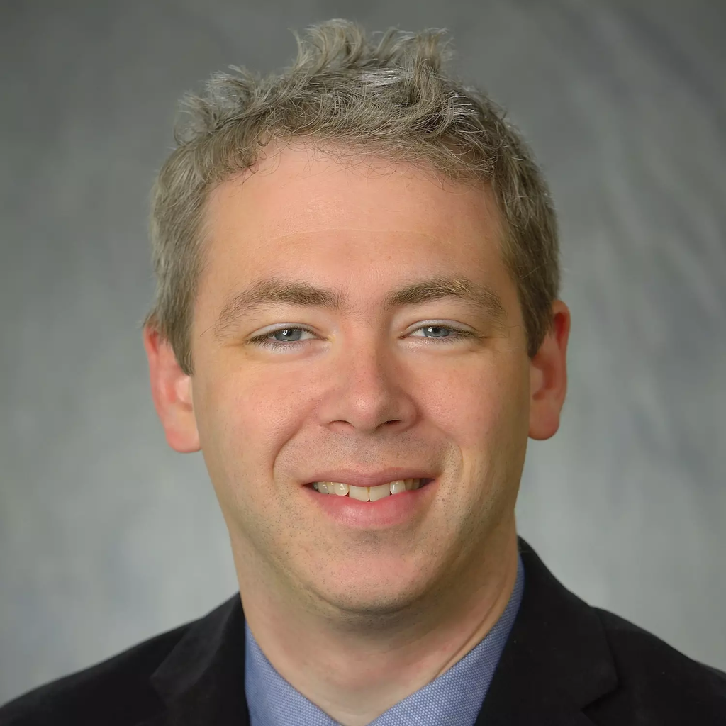

**Brendan J. Kelly, MD, MS** (he/him) is Assistant Professor of Medicine, Epidemiology & Microbiology at the University of Pennsylvania. Dr. Kelly has advanced training in clinical infectious diseases, molecular epidemiology, microbiology, and microbial ecology. He directs the MOTION lab, overseeing all projects conducted in the lab and leading the lab’s collaboration with the Center for the Study of Antibiotic Resistance (C-STAR) at the University of Pennsylvania. His research focuses on the mechanisms of colonization resistance and the application of microbiome-based therapeutics to address the public health threat posed by antimicrobial resistance. Outside of lab, he enjoys walking around Philadelphia, listening to live music, and bodysurfing at the Jersey Shore – especially when joined by his family. Additional information can be found here.

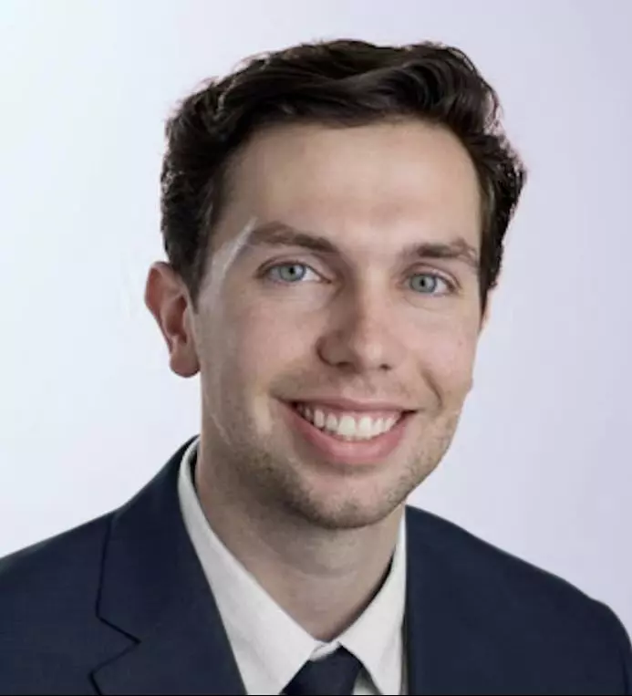

**Mark Burnett,** (he/him) is Administrative Coordinator at the University of Pennsylvania. Mark has been working in the research administrative setting since 2019, specializing in organizational operations and digital strategy. Previously, Mark supported research for the Center for Clinical Epidemiology and Biostatistics and the Antimicrobial Resistance, Epidemiology, and Stewardship Research Collaborative. He is responsible for maintaining research equipment, internal and external communications, event coordination, and administrative operations for the MOTION Lab. Outside of the lab, Mark spends his time outdoors or attending concerts.

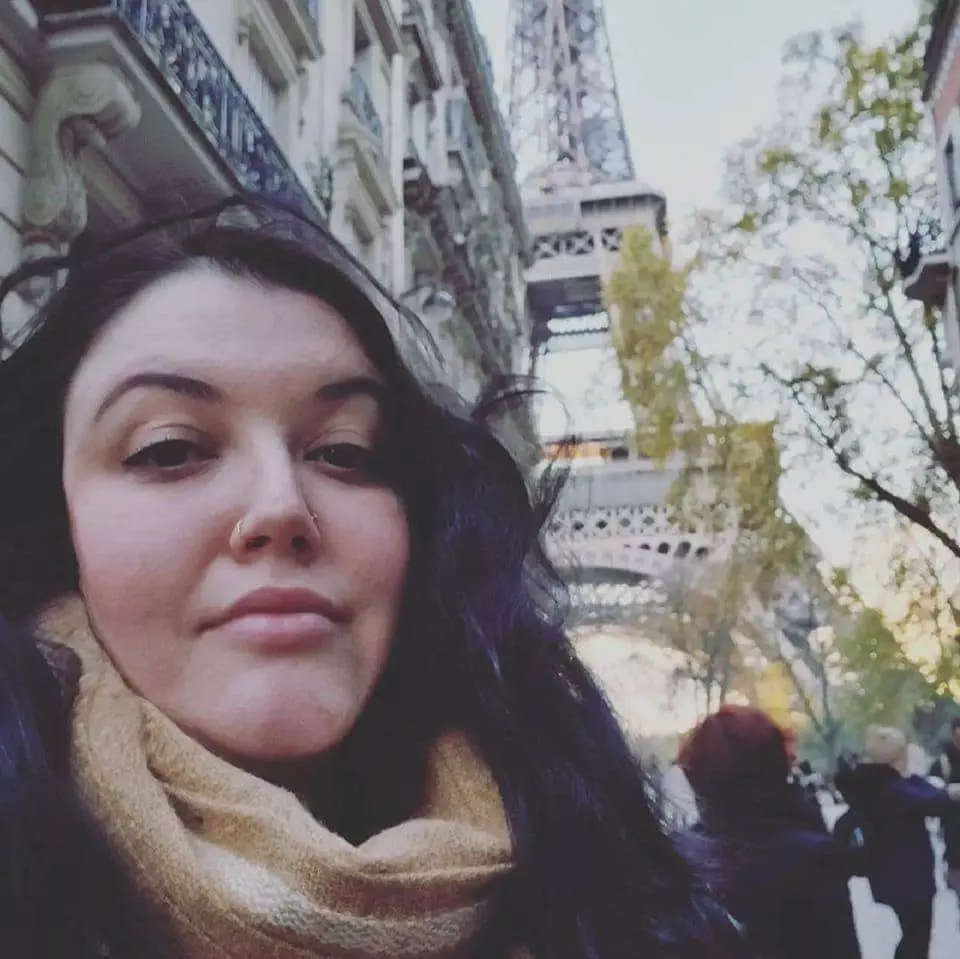

**Laura L. Cowden, MS** (she/her) is Laboratory Manager at the University of Pennsylvania. Laura received her Masters degree in Neuroscience at Drexel University where she studied the rescue effect of the upregulation of a particular heat-shock protein on a polyglutamine expansion model (Huntington’s Disease) in C. elegans. Her work focuses on multi-drug resistant gram negative bacteria and the use of fecal microbiota transplantation to treat C. difficile and MDRO infections. Outside of the lab, she enjoys crocheting, traveling and refurbishing her West Philly victorian home.

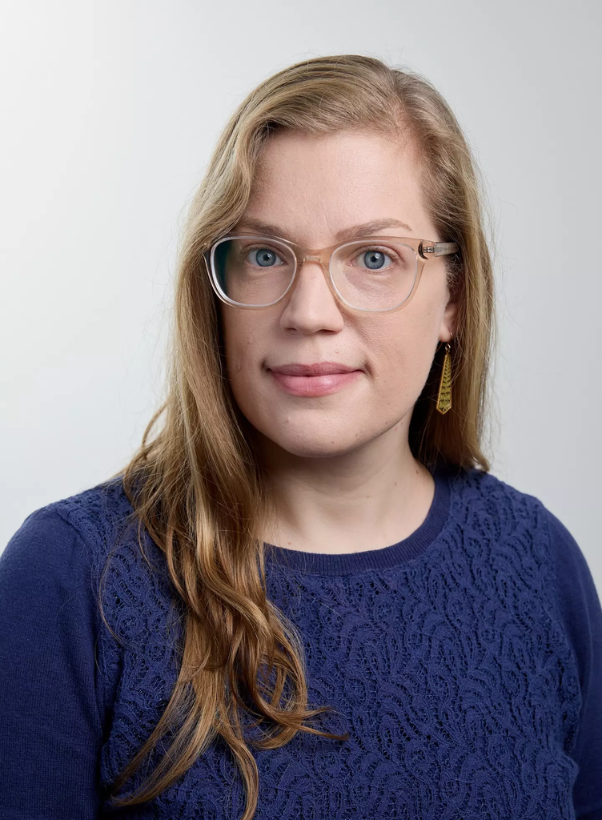

**Leigh Cressman, MA** (she/her) is Senior Data Analyst at the University of Pennsylvania. She got her start as a data analyst in the social sciences, but her interest in public health led her to pursue a career in epidemiology. She has been working with the group since 2016, focusing primarily on the extraction and analysis of EHR data. Her research interests include clinical informatics and the application of natural language processing (NLP) for antimicrobial stewardship. In her free time, she enjoys studying languages and traveling abroad, tending the native pollinator permaculture garden in her Philadelphia backyard, and growing her own food. Additional information can be found [here](https://github.com/LeighCressman).

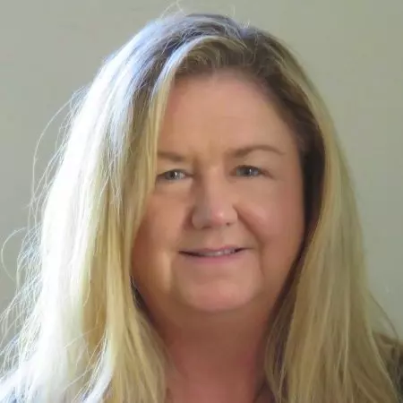

**Anne Jaskowiak, BSW, MS** (she/her) is Clinical Research Project Manager at the University of Pennsylvania. After a successful career as a Program Manager in private industry, Anne came to the University of Pennsylvania Center for Clinical Epidemiology and Biostatistics in 2009 to utilize her skills, education, training and interests in an academic medical environment. She obtained her Master’s of Science degree from Drexel University, with the primary focus on the organization and management of clinical research trials. Anne has logistically coordinated clinical and epidemiological projects in cardiology and infectious diseases. Within the Motion Lab, Anne supports Dr. Kelly’s research work using fecal microbiota transplantation as a therapeutic intervention for C. difficile and MDRO infections. Her passions outside of work include yoga, kayaking, hiking, reading murder mysteries, and spending time with family and friends.

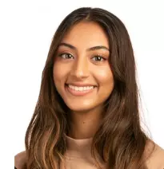

**Alexa Patel,** (she/her/hers) is Research Specialist at the University of Pennsylvania. Prior to joining the MOTION lab, she studied a protective immunity effect in chronically infected Drosophila melanogaster. Her work focuses on antibiotic susceptibility testing on multidrug-resistant gram-negative bacteria. Outside of the lab, she enjoys exploring Philadelphia through discovering new places to eat or trying new workout classes with friends.

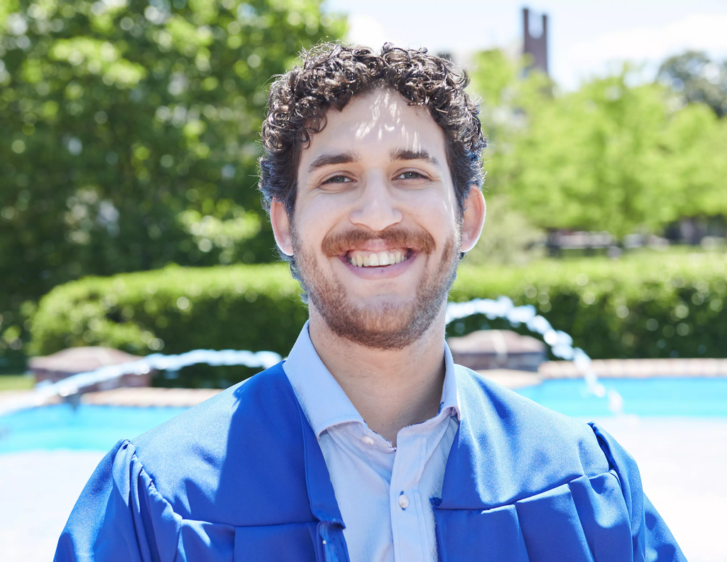

**Dylan Tapper, BS** (he/him) is Research Specialist at the University of Pennsylvania. He previously worked on maximized isopropanol production in a synthetic, syntrophic, co-culture of Clostridium acetobutylicum and Clostridum ljungdahlii. In the MOTION lab, his work mainly focuses on the efficacy of using FMT to combat MDROs. Also working on creating bio repositories for MDROs and C. Diff. Outside of lab, he enjoys playing chess, finding new music and exploring Philly.

[figure not shown]

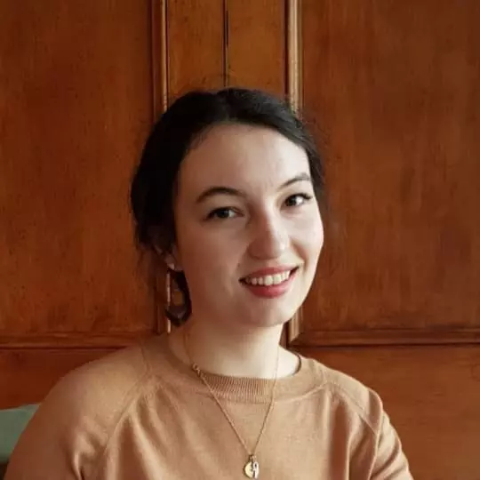

**Emilia C. Wilkins, MS** (she/her) is Research Specialist at the University of Pennsylvania. Emilia recieved her masters in the epidemiology of infectious diseases and antimicrobial resistance.She focused on using genomic analysis and molecular epidemiology to inform public health. She processes metagenomic sequence data and performing analysis to characterize the microbiome and understand its relationship with disease. Outside of work, Emilia loves catching a Phillies game at the Bank, spending a day at the shore, and playing with her dogs.

### Lab Partners

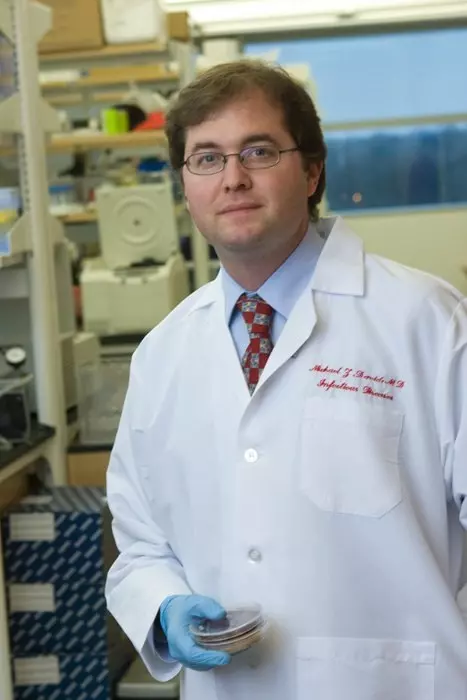

**Michael Z. David, MD, PhD** (he/him) is Assistant Professor at the University of Pennsylvania. Prior to joining the Motion Lab, he studied the molecular and clinical epidemiology of Staphylococcus aureus in the community and in healthcare facilities.. He is now studying the adaptation of S. aureus to the human body and to the healthcare environment. He is interested in the prevention of S. aureus infections and strain differences that underlie infections with, transmission of, and colonization of the human body by S. aureus. He enjoys reading history, photography, and travel. Additional information can be found [here](https://www.cceb.med.upenn.edu/bio/michael-zdenek-david-ms-md-phd).

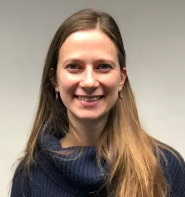

**Lauren Dutcher, MD, MSCE** (she/her) is Assistant Professor at the University of Pennsylvania. Dr. Dutcher’s research focuses on understanding antimicrobial utilization patterns and assessing the impact of antimicrobial stewardship interventions on patient and population outcomes. Outside of work, Dr. Dutcher enjoys hiking, travel, and trying new Philadelphia restaurants. Additional information can be found [here](https://www.med.upenn.edu/apps/faculty/index.php/g349/p8363266).

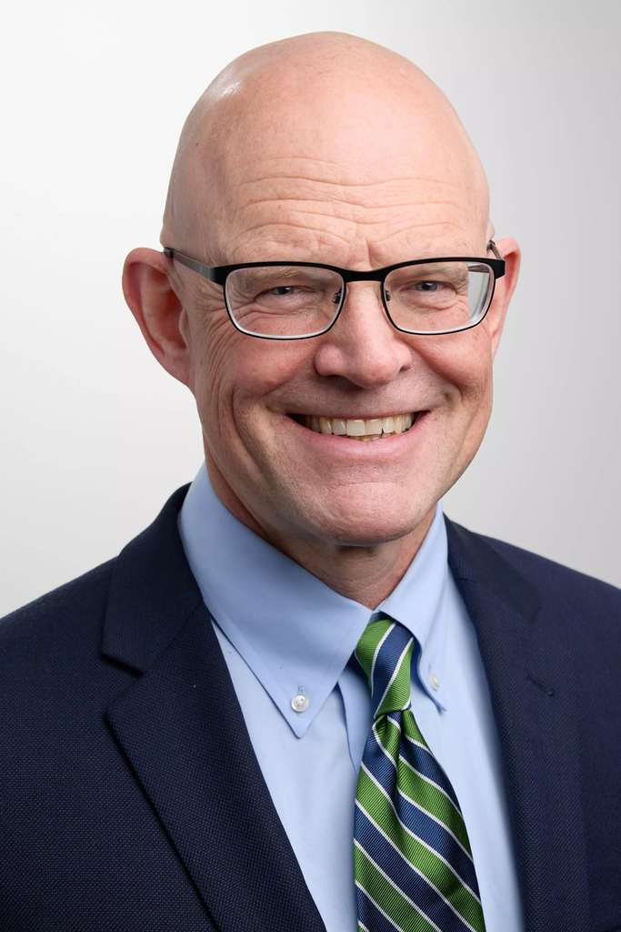

**Ebbing Lautenbach, MD, MPH, MSCE** (he/his/him) is Robert Austrian Professor of Medicine and Epidemiology at the University of Pennsylvania. Prior to joining the MOTION lab, he studied the epidemiology of antimicrobial resistance in healthcare and community settings. His work focuses on understanding the complex interplay of the clinical and molecular epidemiology of antibiotic-resistant colonization and infection. This work focuses primarily on multidrug-resistant gram-negative bacteria in hospital and community settings, both in domestic and international sites. Outside of lab, he enjoys running (most recently the Acadia Marathon in Maine), playing guitar, and traveling. Additional information can be found [here](https://www.cceb.med.upenn.edu/bio/ebbing-lautenbach-md-mph-msce).

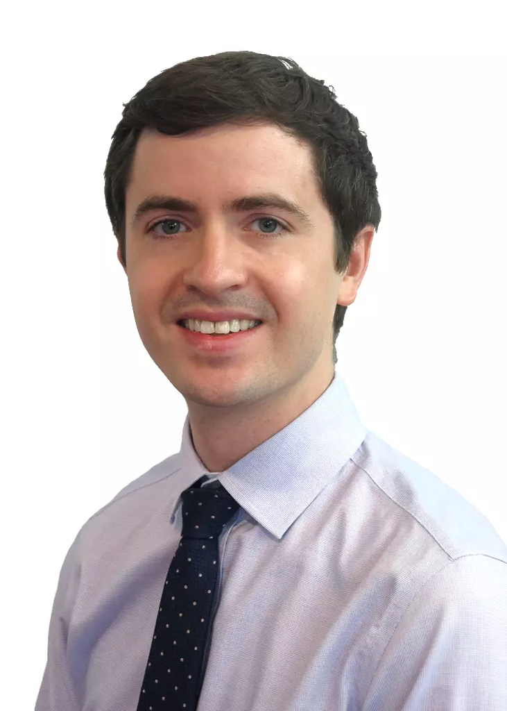

**Matthew J. Ziegler, MD, MSCE** (he/his/him) is Assistant Professor of Medicine at the University of Pennsylvania. His clinical research program focuses on the prevention of healthcare-associated infections in immunocompromised patients and the molecular epidemiology of multidrug-resistant organisms (MDROs) within the hospital built environment. Outside of work, he enjoys woodworking and going to Philly parks with his family.